# Assignment 5: Visualization Audit

Author

Krishaant Pathmanathan

## How to reproduce this file

Render from the repository root (`_quarto.yml` sets `execute-dir: project`, so every path below is relative to the project root, not this folder):

```
quarto render assignments/assignment05-visualization/submission/visualization-audit.qmd
```

Rendering re-reads `examples/nhanes-equity/data/nhanes_equity_v6.csv` and re-exports `corrected-plot.png` into this submission folder.

## Setup

```r
library(readr)
library(dplyr)
library(ggplot2)

nhanes <- read_csv("examples/nhanes-equity/data/nhanes_equity_v6.csv",
                    show_col_types = FALSE)
dim(nhanes)
```

```
[1] 105626     18
```

## Part 1: Audit of the flawed plot starter

`flawed-plot-code.R` compares mean BMI by income group at the first and last NHANES cycle only. Reproducing its logic here (without the `ggsave`/file-path block, which is just a run helper) to see what it actually shows:

```r
cycle_levels <- sort(unique(nhanes$Cycle))
endpoint_cycles <- c(cycle_levels[1], cycle_levels[length(cycle_levels)])

flawed_summary <- nhanes |>
  filter(!is.na(BMI), !is.na(IncomeGroup), Cycle %in% endpoint_cycles) |>
  group_by(Cycle, IncomeGroup) |>
  summarise(mean_bmi = mean(BMI), n = n(), .groups = "drop")

flawed_summary
```

```
# A tibble: 6 x 4
  Cycle     IncomeGroup        mean_bmi     n
  <chr>     <chr>                 <dbl> <int>
1 1999-2000 High Income (>3.5)     25.3  1804
2 1999-2000 Low Income (<1.3)      24.3  2831
3 1999-2000 Middle Income          25.4  2616
4 2021-2023 High Income (>3.5)     27.2  2665
5 2021-2023 Low Income (<1.3)      27.0  1902
6 2021-2023 Middle Income          27.6  2813
```

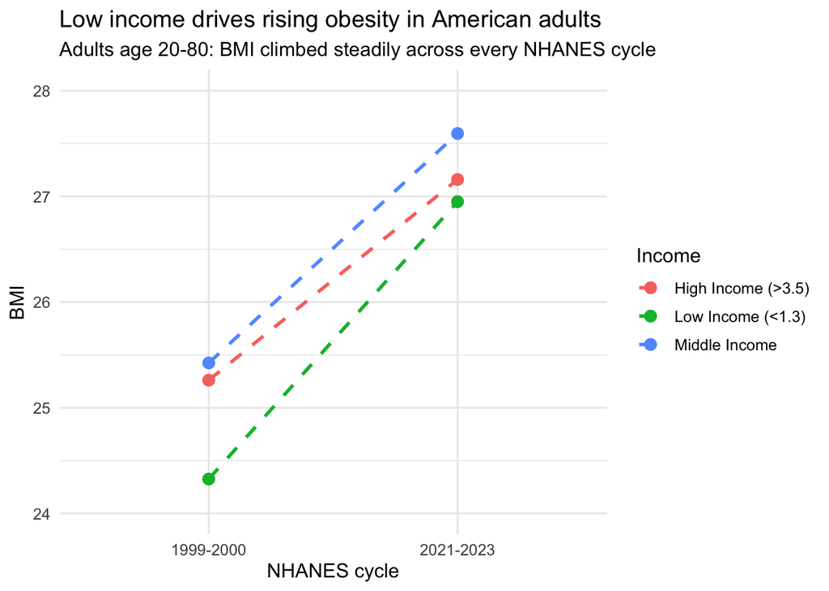

Flawed plot as written by the starter script.

```r
flawed_plot <- ggplot(
  flawed_summary,
  aes(x = Cycle, y = mean_bmi, color = IncomeGroup, group = IncomeGroup)
) +
  geom_point(size = 3) +
  geom_line(linetype = "dashed", linewidth = 1) +
  scale_y_continuous(limits = c(24, 28)) +
  labs(
    title = "Low income drives rising obesity in American adults",
    subtitle = "Adults age 20-80: BMI climbed steadily across every NHANES cycle",
    x = "NHANES cycle",
    y = "BMI",
    color = "Income"
  ) +
  theme_minimal(base_size = 12)

flawed_plot
```

**Issues found in the flawed starter** (see `visual-audit-note.md` for the full table):

1. **Causal title.** “Low income drives rising obesity” claims causation from a cross-sectional, unweighted, descriptive comparison.
2. **Age claim does not match the code.** The subtitle says “Adults age 20-80,” but the pipeline never filters on `Age`. The summary silently includes every age in the file (0-85), including infants and children, under a title about “American adults.”
3. **Truncated y-axis.** `scale_y_continuous(limits = c(24, 28))` starts well above zero, which visually doubles the apparent gap between income groups.
4. **Only 2 of 11 cycles shown, but captioned as “every… cycle.”** Using only the endpoint cycles and drawing a line between them manufactures a “steady climb” that the two points alone cannot demonstrate.
5. **Missingness dropped silently.** `filter(!is.na(IncomeGroup))` removes 9415 rows with no missingness count reported anywhere in the plot or caption.

## Part 2: My own initial draft

My descriptive question: **how does mean BMI differ by household income group in the most recent NHANES cycle?** First pass, before the audit:

```r
draft_summary <- nhanes |>
  filter(!is.na(BMI), !is.na(IncomeGroup), Cycle == "2021-2023") |>
  group_by(IncomeGroup) |>
  summarise(mean_bmi = mean(BMI), n = n(), .groups = "drop")

draft_summary
```

```
# A tibble: 3 x 3
  IncomeGroup        mean_bmi     n
  <chr>                 <dbl> <int>
1 High Income (>3.5)     27.2  2665
2 Low Income (<1.3)      27.0  1902
3 Middle Income          27.6  2813
```

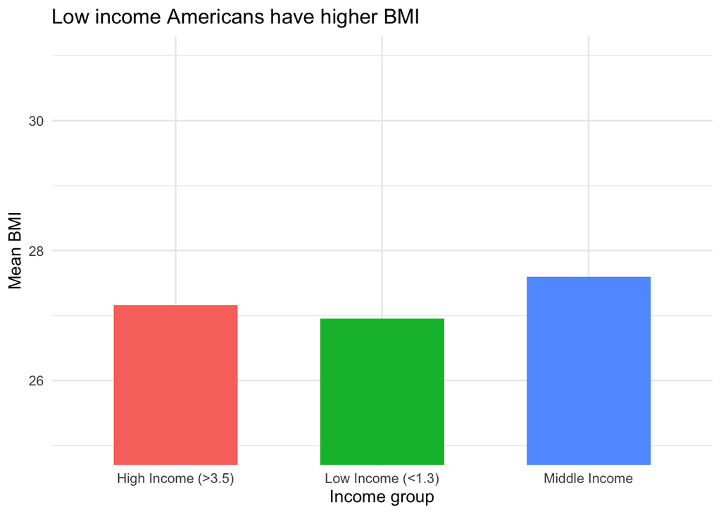

My initial draft, before the audit.

```r
draft_plot <- ggplot(draft_summary, aes(x = IncomeGroup, y = mean_bmi, fill = IncomeGroup)) +
  geom_col(width = 0.6) +
  coord_cartesian(ylim = c(25, 31)) +
  labs(
    title = "Low income Americans have higher BMI",
    x = "Income group",
    y = "Mean BMI"
  ) +
  theme_minimal(base_size = 12) +
  theme(legend.position = "none")

draft_plot
```

## Part 3: Revised, corrected plot

The revision: restrict to adults aged 20-80 (so “BMI by income group” is not mixing in pediatric growth-related BMI), show **all 11 cycles** instead of two endpoints, start the BMI axis at 0, drop the causal/population framing, and report the sample sizes behind the lines.

```r
adults <- nhanes |> filter(Age >= 20, Age <= 80)

corrected_summary <- adults |>
  filter(!is.na(BMI), !is.na(IncomeGroup)) |>
  group_by(Cycle, IncomeGroup) |>
  summarise(mean_bmi = mean(BMI), n = n(), .groups = "drop")

n_dropped <- nrow(adults) - nrow(adults |> filter(!is.na(BMI), !is.na(IncomeGroup)))
n_total_adults <- nrow(adults |> filter(!is.na(BMI), !is.na(IncomeGroup)))

tibble(adults_age_20_80 = nrow(adults),
       dropped_missing_bmi_or_income = n_dropped,
       analyzed = n_total_adults)
```

```
# A tibble: 1 x 3
  adults_age_20_80 dropped_missing_bmi_or_income analyzed
             <int>                         <int>    <int>
1            57137                          6286    50851
```

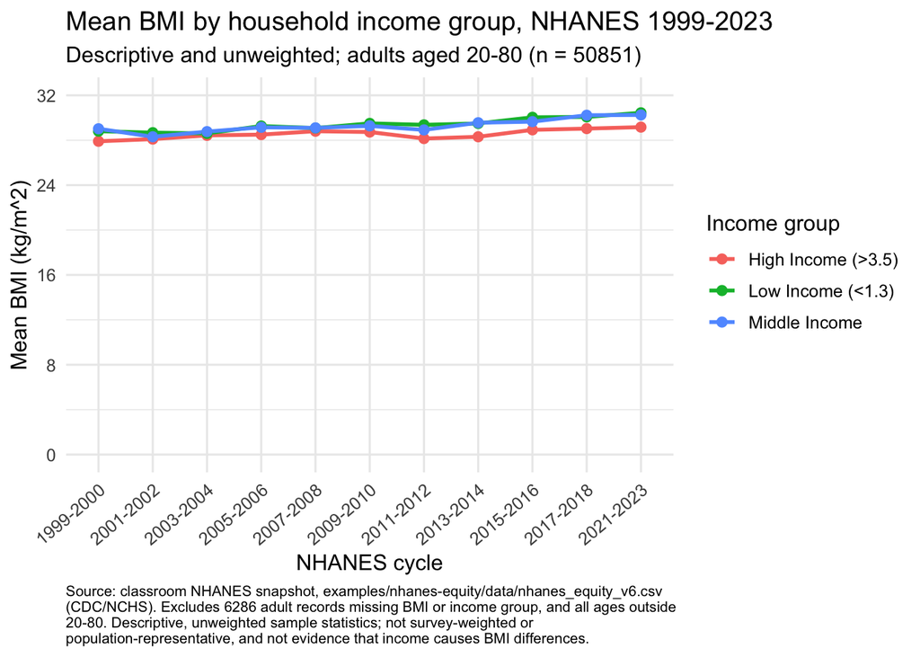

Corrected plot: full axis, all cycles, descriptive framing, sample sizes stated.

```r
corrected_plot <- ggplot(
  corrected_summary,
  aes(x = Cycle, y = mean_bmi, color = IncomeGroup, group = IncomeGroup)
) +
  geom_line(linewidth = 1) +
  geom_point(size = 2.2) +
  scale_y_continuous(limits = c(0, 32), breaks = seq(0, 32, 8)) +
  labs(
    title = "Mean BMI by household income group, NHANES 1999-2023",
    subtitle = paste0(
      "Descriptive and unweighted; adults aged 20-80 (n = ", n_total_adults, ")"
    ),
    x = "NHANES cycle",
    y = "Mean BMI (kg/m^2)",
    color = "Income group",
    caption = paste(
      strwrap(
        paste0(
          "Source: classroom NHANES snapshot, examples/nhanes-equity/data/nhanes_equity_v6.csv (CDC/NCHS). ",
          "Excludes ", n_dropped, " adult records missing BMI or income group, and all ages outside 20-80. ",
          "Descriptive, unweighted sample statistics; not survey-weighted or population-representative, ",
          "and not evidence that income causes BMI differences."
        ),
        width = 95
      ),
      collapse = "\n"
    )
  ) +
  theme_minimal(base_size = 12) +
  theme(
    plot.caption = element_text(hjust = 0, size = 8),
    axis.text.x = element_text(angle = 40, hjust = 1)
  )

corrected_plot
```

```r
ggsave(
  "assignments/assignment05-visualization/submission/corrected-plot.png",
  corrected_plot, width = 9, height = 6.5, dpi = 150
)
```

## Connection to Assignment 4

The `IncomeGroup`, `BMI`, and `Age` columns and the unweighted/descriptive caveat used here are the same ones checked for parity in Assignment 4, which is why the missingness counts for `IncomeGroup` and `BMI` match what was reported there.